# Test a Perceptual Phenomenon

### Analyzing the Stroop Effect

Perform the analysis in the space below. Remember to follow [the instructions](https://docs.google.com/document/d/1-OkpZLjG_kX9J6LIQ5IltsqMzVWjh36QpnP2RYpVdPU/pub?embedded=True) and review the [project rubric](https://review.udacity.com/#!/rubrics/71/view) before submitting. Once you've completed the analysis and write-up, download this file as a PDF or HTML file, upload that PDF/HTML into the workspace here (click on the orange Jupyter icon in the upper left then Upload), then use the Submit Project button at the bottom of this page. This will create a zip file containing both this .ipynb doc and the PDF/HTML doc that will be submitted for your project.

(1) What is the independent variable? What is the dependent variable?

The independant variables are the conditions of the test(whether or not the colour and word name were different or the same. Therefore, the independant variables are the Congruent and Inconcruent conditions.

The dependant variable is the reaction time between stimulus and response. (i.e The time it takes participants to complete the task)

(2) What is an appropriate set of hypotheses for this task? Specify your null and alternative hypotheses, and clearly define any notation used. Justify your choices.

### Hypothesis:

#### Null Hypothesis:

The stroop effect does not interfere with participant's reaction times.

#### Alternative Hypothesis:

Conditions under which participants are tested have significantly different reaction times

$$H_0: \mu_{c} - \mu_{i} = 0$$ $$H_1: \mu_{c} - \mu_{i} \neq 0$$

Where $\mu_{c}$ represents the mean times of Congruent responses and $\mu_{i}$ represents the mean times of Incongruent responses.

(2b) We will perform a **paired t-test**:

- the same individuals were treated to the two different conditions presented in the study(whether or not the colour and word name were different or the same), and we need compare the differences of the participants response times in order to determine the significance of the stroop effect
- We are testing the differences before and after some treatment on the same individuals.
- The ability to compare the means of the dataset for the pre and post test validates the benefit of this test selection

The sample size is small (24<30)

- The population variance is unknown
- We are assuming that the data is normally distributed.

### **Expected outcomes of the test**

The response times under Incongruent conditions will be longer tham the response times under Congruent conditions.Results from the statistical test will prove that we reject the null in favour of the alternative.

(3) Report some descriptive statistics regarding this dataset. Include at least one measure of central tendency and at least one measure of variability. The name of the data file is 'stroopdata.csv'.

```python
import pandas as pd
#from scipy import stats
from scipy.stats import t as stat
import seaborn as sns
import matplotlib.pyplot as plt
%matplotlib inline
df = pd.read_csv('stroopdata.csv')
df.head()
```

|  | Congruent | Incongruent |
| --- | --- | --- |
| 0 | 12.079 | 19.278 |
| 1 | 16.791 | 18.741 |
| 2 | 9.564 | 21.214 |
| 3 | 8.630 | 15.687 |
| 4 | 14.669 | 22.803 |

```python
df.shape
```

[output not shown]

```python
df.describe()
```

|  | Congruent | Incongruent |
| --- | --- | --- |
| count | 24.000000 | 24.000000 |
| mean | 14.051125 | 22.015917 |
| std | 3.559358 | 4.797057 |
| min | 8.630000 | 15.687000 |
| 25% | 11.895250 | 18.716750 |
| 50% | 14.356500 | 21.017500 |
| 75% | 16.200750 | 24.051500 |
| max | 22.328000 | 35.255000 |

```python
#Display some measures of central tendency for independant
#variables individualy
meanC = df['Congruent'].mean()
medC = df['Congruent'].median()
meanC, medC
```

```
(14.051124999999999, 14.3565)
```

```python
meanI = df['Incongruent'].mean() #reaction times are longer on average
medI = df['Incongruent'].median()
meanI, medI
```

```
(22.015916666666666, 21.0175)
```

```python
#measure of variability
varC = df['Congruent'].var()
stdC = df['Congruent'].std()
varC, stdC
```

```
(12.669029070652176, 3.5593579576451955)
```

```python
varI = df['Incongruent'].var()
stdI = df['Incongruent'].std()
varI, stdI
```

```
(23.011757036231884, 4.7970571224691376)
```

```python
#To make data look neater, print mean,median and standard deviation in a table
info = [[int(24),int(24)],[meanC, meanI],[medC, medI],[stdC, stdI]]
table = pd.DataFrame(info,index=['Sample Size','Mean','Median','Standard Deviation'], columns=['Congruent','Incongruent'])
table
```

|  | Congruent | Incongruent |
| --- | --- | --- |
| Sample Size | 24.000000 | 24.000000 |
| Mean | 14.051125 | 22.015917 |
| Median | 14.356500 | 21.017500 |
| Standard Deviation | 3.559358 | 4.797057 |

Reaction times are longer, on average, under Incongruent conditions than Congruent conditions

We've observed that for the Congruent data the mean < the median and therefore would suggest that the data is left-skewed.

For the Incongruent data the mean > the median, suggesting the data is right-skewed.

**This is not conclusive, we will explore the distribution of the data further.**

(4) Provide one or two visualizations that show the distribution of the sample data. Write one or two sentences noting what you observe about the plot or plots.

```
Text(0.5,1,'Congruent Conditions Q-Q Plot')
```

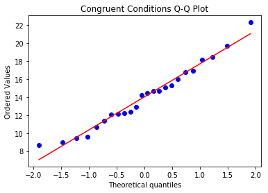

```python
# Build the visualizations here
stats.probplot(df['Congruent'], plot= plt)
plt.title('Congruent Conditions Q-Q Plot')
```

```
Text(0.5,1,'Incongruent Conditions Q-Q Plot')
```

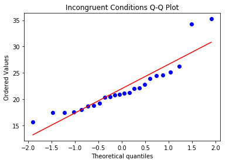

```python
#plt.hist(df['Incongruent']);
stats.probplot(df['Incongruent'], plot= plt)
plt.title('Incongruent Conditions Q-Q Plot')
```

The Q-Q Plot, representing Incongruent Conditions, shows that some points deviate much further from the mean. This may indicate possible outliers

```python
#df[['Incongruent']].plot(kind = 'box')
```

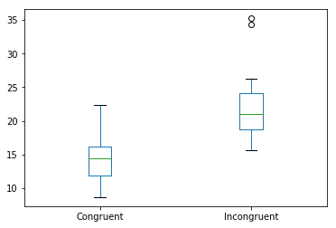

```python
df[['Congruent', 'Incongruent']].plot(kind = 'box')
```

There are outliers shown on our box plot, just above the Incongruent plot. The position of the median also suggests that the data is skewed to the left for Congruent data and right skewed for Incongruent data. But, only slight skewedness is observed here.

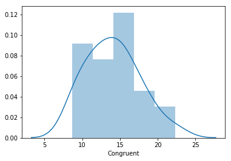

```python
#Explore distribution of data further
sns.distplot(df['Congruent'])
```

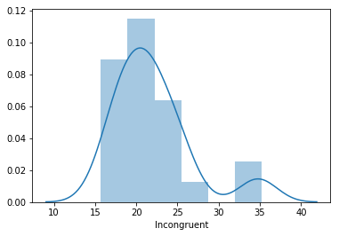

```python
sns.distplot(df['Incongruent'])
```

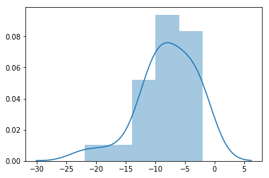

```python
sns.distplot(df['Congruent'] - df['Incongruent'])
```

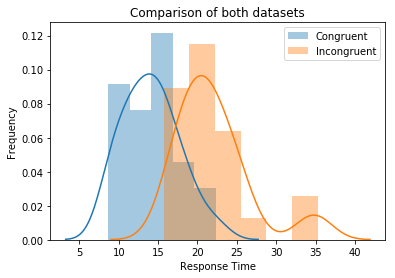

```python
#Comparison of both datasets
sns.distplot(df['Congruent'], label = 'Congruent')
sns.distplot(df['Incongruent'], label = 'Incongruent')
plt.xlabel('Response Time')
plt.ylabel('Frequency')
plt.title('Comparison of both datasets')
plt.legend()
```